# Bike Sharing Forecasting

## Introduction

In this test task I have an opportunity to demonstrate my skills on Data Science from various angles - processing data, analyzing and vizalizing it, finding insights, applying predictive techniques and explaining my reasoning about it.

The task is based around a bike sharing dataset openly available at UCI Machine Learning Repository [1].

Please go through the steps below with necessary code and comment

## Part 1 - Data Loading and Environment Preparation

**Tasks:**

1. Prepared a Python 3 virtual environment (with virtualenv command). requirements.txt output of pip freeze is included as part of submission.
2. Load the data from UCI Repository and put it into the same folder with the notebook. The link to it is https://archive.ics.uci.edu/ml/datasets/bike+sharing+dataset . Here is an available mirror in case the above website is down: https://data.world/uci/bike-sharing-dataset
3. Load the data into Python runtime as Pandas dataframe.
4. Split the data into two parts. One dataset containing the last 15 days and one dataset with the rest.

```python
# Run it only Once
# tried to get the bare minimum to get a new conda env working
conda_path = ''
try:
    conda_path = !which conda
finally:
    print('')

if (len(conda_path) == 0):
    print('installing miniconda')
    !wget https://repo.continuum.io/miniconda/Miniconda3-4.5.4-Linux-x86_64.sh && bash Miniconda3-4.5.4-Linux-x86_64.sh -bfp /usr/local
    !conda update conda -y -q
    !source /usr/local/etc/profile.d/conda.sh
    !conda init
    !conda install -n root _license -y -q
else:
    print('found miniconda')

conda_envs = !conda env list
res = [i for i in conda_envs if 'Bikesharingenv' in i]
if (len(res) == 0):
    print('not found Bikesharingenv env', len(res))
    !conda create -y -q --name Bikesharingenv python=3.6
else:
    print('found Bikesharingenv env', len(res))
```

```python
%%bash
source activate Bikesharingenv

python
import sys
# maybe only need this the first time we run this notebook
sys.path.append('/usr/local/lib/python3.6/site-packages')

print("Python version")
print(sys.version)
```

# import Libraries

```python
#pip install rfpimp
```

```python
# data visualisation and manipulation
import os
import numpy as np
import zipfile
import joblib
import xgboost as xgb
from six.moves import urllib
import pandas as pd
import matplotlib.pyplot as plt
from matplotlib import style
import seaborn as sns
import math
from scipy import stats
from datetime import datetime
#import rfpimp
# Ignore  the warnings
import warnings
warnings.filterwarnings('always')
warnings.filterwarnings('ignore')

# sets matplotlib to inline and displays graphs below the corressponding cell.
%matplotlib inline
style.use('fivethirtyeight')
sns.set(style='whitegrid',color_codes=True)

#regression
from sklearn.linear_model import LinearRegression,Ridge,Lasso,RidgeCV
from sklearn.ensemble import RandomForestRegressor,BaggingRegressor,GradientBoostingRegressor,AdaBoostRegressor
from sklearn.svm import SVR
from sklearn.neighbors import KNeighborsRegressor

#evaluation metrics
from sklearn.metrics import mean_squared_log_error,mean_squared_error, r2_score, mean_absolute_error # for regression
from sklearn import  metrics
#model selection
from sklearn.model_selection import train_test_split,cross_validate
from sklearn.feature_selection import RFE
from sklearn.model_selection import KFold
from sklearn.model_selection import GridSearchCV,RandomizedSearchCV
from sklearn.preprocessing import MinMaxScaler

# tensorflow
import tensorflow as tf
from tensorflow import keras
from tensorflow.keras import Sequential, layers
from tensorflow.keras.layers import Embedding,Flatten, Dense, Input,Concatenate,Reshape
from tensorflow.keras import Model
#from keras.models import load_model

# Statsmodel
import statsmodels.api as sm
from statsmodels.tsa.seasonal import seasonal_decompose
from statsmodels.graphics.tsaplots import plot_acf,plot_pacf
from statsmodels.tsa.stattools import adfuller
```

# Load dataset, run each time after colab recycles dataset

```python
DOWNLOAD_ROOT = "https://archive.ics.uci.edu/ml/machine-learning-databases/00275/"
BIKE_PATH = os.path.join("sample_data", "bike_sharing")
BIKE_URL = DOWNLOAD_ROOT + "Bike-Sharing-Dataset.zip"
```

```python
def fetch_housing_data(bike_url=BIKE_URL, bike_path=BIKE_PATH):
 if not os.path.isdir(bike_path):
   os.makedirs(bike_path)
 tgz_path = os.path.join(bike_path, "Bike-Sharing-Dataset.zip")
 urllib.request.urlretrieve(bike_url, tgz_path)
 housing_tgz = zipfile.ZipFile(tgz_path,'r')
 housing_tgz.extractall()
 housing_tgz.close()
```

```python
fetch_housing_data()
```

```python
def load_housing_data(bike_path=BIKE_PATH):
  csv_path = os.path.join(bike_path, "day.csv")
  return pd.read_csv(csv_path)
```

```python
rides = pd.read_csv('hour.csv')
print(rides.shape)
rides[:2]
```

```
(17379, 17)
```

|  | instant | dteday | season | yr | mnth | hr | holiday | weekday | workingday | weathersit | temp | atemp | hum | windspeed | casual | registered | cnt |
| --- | --- | --- | --- | --- | --- | --- | --- | --- | --- | --- | --- | --- | --- | --- | --- | --- | --- |
| 0 | 1 | 2011-01-01 | 1 | 0 | 1 | 0 | 0 | 6 | 0 | 1 | 0.24 | 0.2879 | 0.81 | 0.0 | 3 | 13 | 16 |
| 1 | 2 | 2011-01-01 | 1 | 0 | 1 | 1 | 0 | 6 | 0 | 1 | 0.22 | 0.2727 | 0.80 | 0.0 | 8 | 32 | 40 |

few hundered hours of records are missing, assumiing that there was no sharing of bike during those hours, creating entire hourly observtion for better training. Eg - i will train lstm on sequence of last 7 days of data to predict next 24 hours, and i want to avoid missing hours in those 7 days

```python
df = pd.DataFrame(
        {'Hours': pd.date_range('2011-01-02', '2012-12-31', freq='1H', closed='left')}
     )
print(df.shape)
df['hr'] = pd.to_datetime(df['Hours'], format='%H:%M:%S').dt.hour
df['dteday'] = pd.to_datetime(df['Hours'], format='%YY:%mm:%dd').dt.date
df[:2]
```

```
(17496, 1)
```

|  | Hours | hr | dteday |
| --- | --- | --- | --- |
| 0 | 2011-01-02 00:00:00 | 0 | 2011-01-02 |
| 1 | 2011-01-02 01:00:00 | 1 | 2011-01-02 |

```python
df =df.drop('Hours',axis=1)
rides = rides.drop('instant',axis=1)
df['dteday'] = pd.to_datetime(df['dteday'])
rides['dteday'] = pd.to_datetime(rides['dteday'])
```

```python
final_data =pd.merge(df,rides,  how='left', on= ['dteday','hr'])
print(final_data.shape)
final_data[:5]
```

```
(17496, 16)
```

|  | hr | dteday | season | yr | mnth | holiday | weekday | workingday | weathersit | temp | atemp | hum | windspeed | casual | registered | cnt |
| --- | --- | --- | --- | --- | --- | --- | --- | --- | --- | --- | --- | --- | --- | --- | --- | --- |
| 0 | 0 | 2011-01-02 | 1.0 | 0.0 | 1.0 | 0.0 | 0.0 | 0.0 | 2.0 | 0.46 | 0.4545 | 0.88 | 0.2985 | 4.0 | 13.0 | 17.0 |
| 1 | 1 | 2011-01-02 | 1.0 | 0.0 | 1.0 | 0.0 | 0.0 | 0.0 | 2.0 | 0.44 | 0.4394 | 0.94 | 0.2537 | 1.0 | 16.0 | 17.0 |
| 2 | 2 | 2011-01-02 | 1.0 | 0.0 | 1.0 | 0.0 | 0.0 | 0.0 | 2.0 | 0.42 | 0.4242 | 1.00 | 0.2836 | 1.0 | 8.0 | 9.0 |
| 3 | 3 | 2011-01-02 | 1.0 | 0.0 | 1.0 | 0.0 | 0.0 | 0.0 | 2.0 | 0.46 | 0.4545 | 0.94 | 0.1940 | 2.0 | 4.0 | 6.0 |
| 4 | 4 | 2011-01-02 | 1.0 | 0.0 | 1.0 | 0.0 | 0.0 | 0.0 | 2.0 | 0.46 | 0.4545 | 0.94 | 0.1940 | 2.0 | 1.0 | 3.0 |

Fill the missing of predictors with back fill interpolation and casuals, registered and count with zero's, as i am assuming bike sharing wasnt done in these hours

```python
cols= [ 'season', 'yr', 'mnth', 'holiday', 'weekday',
       'workingday', 'weathersit', 'temp', 'atemp', 'hum', 'windspeed']
final_data.loc[:,cols] = final_data.loc[:,cols].bfill()
cols_to_replace= [  'casual', 'registered', 'cnt']
final_data[cols_to_replace] = final_data[cols_to_replace].replace(np.nan,0)
```

```python
# 4 o clock data was missing, so count, casual and registered are replaced with zero, and remaining are back filled
final_data[final_data.dteday=='2012-11-08'][3:4]
```

|  | hr | dteday | season | yr | mnth | holiday | weekday | workingday | weathersit | temp | atemp | hum | windspeed | casual | registered | cnt |
| --- | --- | --- | --- | --- | --- | --- | --- | --- | --- | --- | --- | --- | --- | --- | --- | --- |
| 16227 | 3 | 2012-11-08 | 4.0 | 1.0 | 11.0 | 0.0 | 4.0 | 1.0 | 2.0 | 0.3 | 0.2879 | 0.45 | 0.2836 | 0.0 | 0.0 | 0.0 |

Visual test

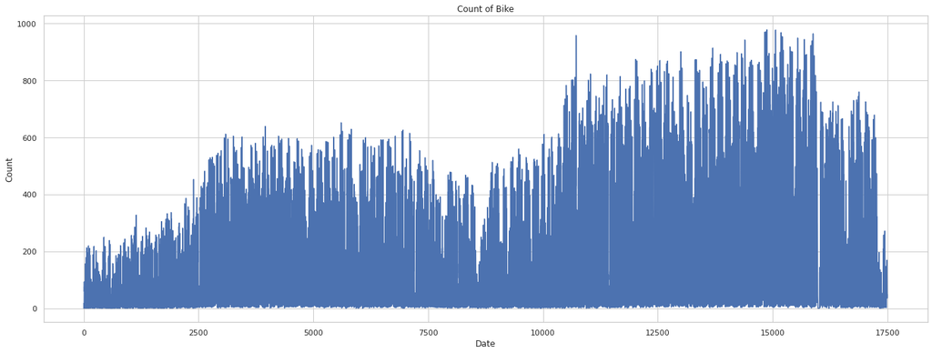

```python
final_data["cnt"].plot(figsize=(20, 8))
plt.xlabel("Date")
plt.ylabel("Count")
plt.title("Count of Bike")
plt.show()
```

Very clear that we have a trend, Let's check stationary -ADF (Augmented Dickey Fuller) Test

```python
def Augmented_Dickey_Fuller_Test_func(series , column_name):

  print (f'Results of Dickey-Fuller Test for column: {column_name}')
  dftest = adfuller(series, autolag='AIC')
  dfoutput = pd.Series(dftest[0:4], index=['Test Statistic',  'p-value','No Lags Used','Number of Observations Used'])
  for key,value in dftest[4].items():
    dfoutput['Critical Value (%s)'%key] = value
  print (dfoutput)
  if dftest[1] <= 0.05:
    print("Conclusion:====>")
    print("Reject the null hypothesis")
    print("Data is stationary")
  else:
    print("Conclusion:====>")
    print("Fail to reject the null hypothesis")
    print("Data is non-stationary")
```

```python
Augmented_Dickey_Fuller_Test_func(final_data['cnt'],'cnt')
```

```
Results of Dickey-Fuller Test for column: cnt
Test Statistic                -7.014222e+00
p-value                        6.798123e-10
No Lags Used                   4.200000e+01
Number of Observations Used    1.745300e+04
Critical Value (1%)           -3.430725e+00
Critical Value (5%)           -2.861706e+00
Critical Value (10%)          -2.566858e+00
dtype: float64
Conclusion:====>
Reject the null hypothesis
Data is stationary
```

Test for stationarity: If the test statistic is less than the critical value, we can reject the null hypothesis (aka the series is stationary). When the test statistic is greater than the critical value, we fail to reject the null hypothesis (which means the series is not stationary).

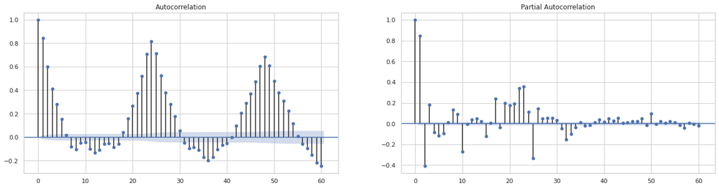

```python
fig, ax = plt.subplots(1,2,figsize=(20,5))
plot_acf(final_data['cnt'], lags=60, ax=ax[0])
plot_pacf(final_data['cnt'], lags=60, ax=ax[1])
plt.show()
```

values can also be expected to depend on it’s previous lagged values

```python
dataframe = pd.DataFrame()
for i in range(24, 0,-1):
  dataframe['t_' + str(i)] = final_data.cnt.shift(i)
final_data = pd.concat([final_data, dataframe], axis=1)
final_data.dropna(inplace=True)
final_data[:2]
```

|  | hr | dteday | season | yr | mnth | holiday | weekday | workingday | weathersit | temp | atemp | hum | windspeed | casual | registered | cnt | t_24 | t_23 | t_22 | t_21 | t_20 | t_19 | t_18 | t_17 | t_16 | t_15 | t_14 | t_13 | t_12 | … |
| --- | --- | --- | --- | --- | --- | --- | --- | --- | --- | --- | --- | --- | --- | --- | --- | --- | --- | --- | --- | --- | --- | --- | --- | --- | --- | --- | --- | --- | --- | --- |
| 24 | 0 | 2011-01-03 | 1.0 | 0.0 | 1.0 | 0.0 | 1.0 | 1.0 | 1.0 | 0.22 | 0.1970 | 0.44 | 0.3582 | 0.0 | 5.0 | 5.0 | 17.0 | 17.0 | 9.0 | 6.0 | 3.0 | 0.0 | 2.0 | 1.0 | 8.0 | 20.0 | 53.0 | 70.0 | 93.0 | … |
| 25 | 1 | 2011-01-03 | 1.0 | 0.0 | 1.0 | 0.0 | 1.0 | 1.0 | 1.0 | 0.20 | 0.1667 | 0.44 | 0.4179 | 0.0 | 2.0 | 2.0 | 17.0 | 9.0 | 6.0 | 3.0 | 0.0 | 2.0 | 1.0 | 8.0 | 20.0 | 53.0 | 70.0 | 93.0 | 75.0 | … |

```python
final_data.shape
```

```
(17472, 40)
```

```python
validate = final_data.loc[(final_data.dteday >='2012-12-15')]
rides = final_data.loc[(final_data.dteday<'2012-12-15')]
```

```python
print('validate shape {0} \nrest dataset shape {1}'.format(validate.shape,rides.shape))
```

```
validate shape (384, 40)
rest dataset shape (17088, 40)
```

## Part 2 - Feature Engineering

```python
#final_data.isnull().sum()
```

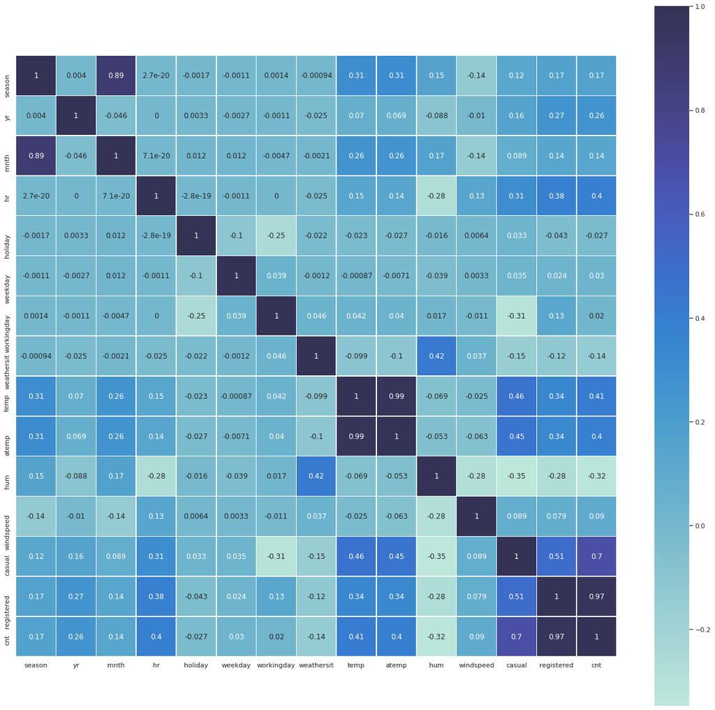

```python
corr = rides[['dteday', 'season', 'yr', 'mnth', 'hr', 'holiday', 'weekday',
       'workingday', 'weathersit', 'temp', 'atemp', 'hum', 'windspeed',
       'casual', 'registered', 'cnt']].corr()
f,axes = plt.subplots(1,1,figsize = (20,20))
sns.heatmap(corr,square=True,annot = True,linewidth = .5,center = 1.4,ax = axes)
```

Casual, registered and cnt are one or the same. month is highly correlated to season as obvious. temp and atemp is same, can drop either of them

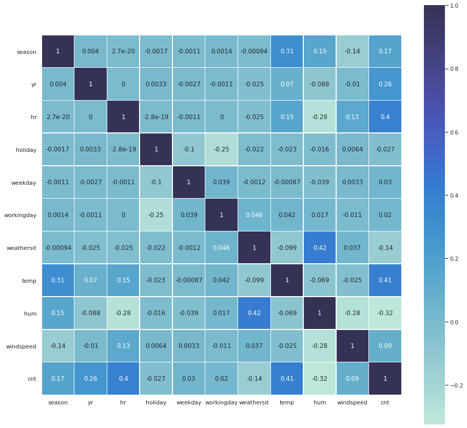

```python
corr = rides[['dteday', 'season', 'yr',  'hr', 'holiday', 'weekday',
       'workingday', 'weathersit', 'temp',  'hum', 'windspeed'
      , 'cnt']].corr()
f,axes = plt.subplots(1,1,figsize = (14,14))
sns.heatmap(corr,square=True,annot = True,linewidth = .5,center = 1.4,ax = axes)
```

```python
lable = final_data.loc[:,['dteday',  'yr', 'mnth', 'hr', 'holiday', 'weekday',
       'workingday',  'temp',  'hum', 'windspeed', 'season',  'weathersit',
        't_24', 't_23', 't_22', 't_21', 't_20',
       't_19', 't_18', 't_17', 't_16', 't_15', 't_14', 't_13', 't_12', 't_11',
       't_10', 't_9', 't_8', 't_7', 't_6', 't_5', 't_4', 't_3', 't_2', 't_1','cnt']]
```

WE CAN DO SOME FEATURE ENGINEERING AND GET SOME NEW FEATURES AND DROP SOME USELESS OR LESS RELEVANT FEATURES.

```python
lable['dteday'] = pd.to_datetime(lable['dteday'])
lable = lable.set_index(['dteday'])
```

```python
lable[:4]
```

| dteday | yr | mnth | hr | holiday | weekday | workingday | temp | hum | windspeed | season | weathersit | t_24 | t_23 | t_22 | t_21 | t_20 | t_19 | t_18 | t_17 | t_16 | t_15 | t_14 | t_13 | t_12 | t_11 | t_10 | t_9 | t_8 | t_7 | … |
| --- | --- | --- | --- | --- | --- | --- | --- | --- | --- | --- | --- | --- | --- | --- | --- | --- | --- | --- | --- | --- | --- | --- | --- | --- | --- | --- | --- | --- | --- | --- |
| 2011-01-03 | 0.0 | 1.0 | 0 | 0.0 | 1.0 | 1.0 | 0.22 | 0.44 | 0.3582 | 1.0 | 1.0 | 17.0 | 17.0 | 9.0 | 6.0 | 3.0 | 0.0 | 2.0 | 1.0 | 8.0 | 20.0 | 53.0 | 70.0 | 93.0 | 75.0 | 59.0 | 74.0 | 76.0 | 65.0 | … |
| 2011-01-03 | 0.0 | 1.0 | 1 | 0.0 | 1.0 | 1.0 | 0.20 | 0.44 | 0.4179 | 1.0 | 1.0 | 17.0 | 9.0 | 6.0 | 3.0 | 0.0 | 2.0 | 1.0 | 8.0 | 20.0 | 53.0 | 70.0 | 93.0 | 75.0 | 59.0 | 74.0 | 76.0 | 65.0 | 53.0 | … |
| 2011-01-03 | 0.0 | 1.0 | 2 | 0.0 | 1.0 | 1.0 | 0.16 | 0.47 | 0.3881 | 1.0 | 1.0 | 9.0 | 6.0 | 3.0 | 0.0 | 2.0 | 1.0 | 8.0 | 20.0 | 53.0 | 70.0 | 93.0 | 75.0 | 59.0 | 74.0 | 76.0 | 65.0 | 53.0 | 30.0 | … |
| 2011-01-03 | 0.0 | 1.0 | 3 | 0.0 | 1.0 | 1.0 | 0.16 | 0.47 | 0.3881 | 1.0 | 1.0 | 6.0 | 3.0 | 0.0 | 2.0 | 1.0 | 8.0 | 20.0 | 53.0 | 70.0 | 93.0 | 75.0 | 59.0 | 74.0 | 76.0 | 65.0 | 53.0 | 30.0 | 22.0 | … |

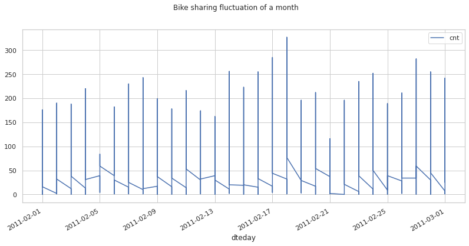

```python
ts= lable[['cnt']]

ts.loc['2011-02-01':'2011-03-01'].plot(figsize = (12,6))
plt.suptitle('Bike sharing fluctuation of a month')
```

traditional time series models like SARIMAX cannot handle multiple seasonalities.SARIMAX models with Fourier series handling the multiple seasonalities can out perform other models

- The main diriving point behind this feature transformation is that we cannot just feed in the hours as 0,1,2,….22,23 to the model, because we need to make the model understand that 0th and 23rd hours are in reality as close as the 0th hour is to the 1st hour. Same for the weekdays and years.

```python
def encode(data, col, max_val):
    data[col + '_sin'] = np.sin(2 * np.pi * data[col]/max_val)
    data[col + '_cos'] = np.cos(2 * np.pi * data[col]/max_val)
    return data
```

```python
lable = encode(lable,'season',4)
lable = encode(lable,'weathersit',4)
lable = encode(lable,'weekday',7)
lable = encode(lable,'mnth',12)
lable = encode(lable,'hr',24)
```

After expirementing, these variables are not showing any significant impact, but i will keep it handy for future use

```python
def cat_temp(x):


  """simple function for categrizing temp (by building decision tree)"""
  if x['temp'] <= 0.27:
      return 0
  elif x['temp'] <= 0.35:
      return 1
  elif x['temp'] <= 0.69:
      return 2
  else:
      return 3
```

```python
 def cat_hum(x):
  """simple function for categrizing hum (by building decision tree)"""
  if x['hum'] <= 0.435:
      return 0
  elif x['hum'] <= 0.625:
      return 1
  elif x['hum'] <= 0.855:
      return 2
  else:
      return 3
```

```python
lable['atemp_windspeed'] = lable[['temp', 'windspeed']].apply(
        lambda x: (0, 1)[(0.2537<=x['windspeed']<=0.2537 or 0.3284<=x['windspeed']<= 0.4925) and
                         (0.6212<=x['temp']<=0.6667)], axis = 1)
```

```python
lable['temp_cat'] = lable[['temp']].apply(cat_temp, axis=1)
lable['hum_cat'] = lable[['hum']].apply(cat_hum, axis=1)
```

```python
lable.columns
```

```
Index(['yr', 'mnth', 'hr', 'holiday', 'weekday', 'workingday', 'temp', 'hum',
       'windspeed', 'season', 'weathersit', 't_24', 't_23', 't_22', 't_21',
       't_20', 't_19', 't_18', 't_17', 't_16', 't_15', 't_14', 't_13', 't_12',
       't_11', 't_10', 't_9', 't_8', 't_7', 't_6', 't_5', 't_4', 't_3', 't_2',
       't_1', 'cnt', 'season_sin', 'season_cos', 'weathersit_sin',
       'weathersit_cos', 'weekday_sin', 'weekday_cos', 'mnth_sin', 'mnth_cos',
       'hr_sin', 'hr_cos', 'atemp_windspeed', 'temp_cat', 'hum_cat'],
      dtype='object')
```

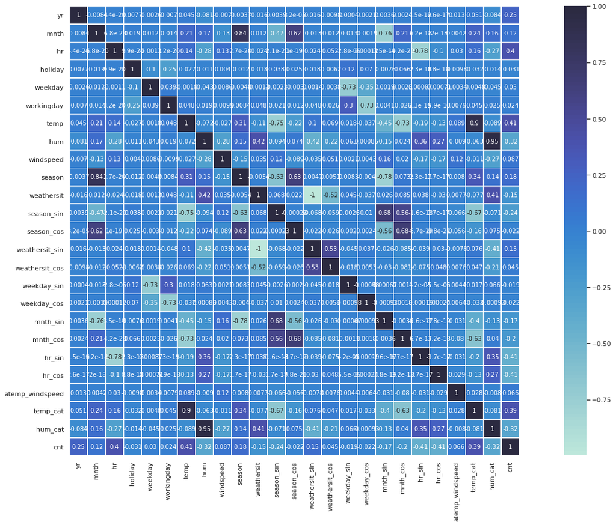

```python
corr = lable[['yr', 'mnth', 'hr', 'holiday', 'weekday', 'workingday', 'temp', 'hum',
       'windspeed', 'season', 'weathersit', 'season_sin', 'season_cos', 'weathersit_sin',
       'weathersit_cos', 'weekday_sin', 'weekday_cos', 'mnth_sin', 'mnth_cos',
       'hr_sin', 'hr_cos', 'atemp_windspeed', 'temp_cat', 'hum_cat','cnt',]].corr()
f,axes = plt.subplots(1,1,figsize = (24,14))
sns.heatmap(corr,square=True,annot = True,linewidth = .5,center = 1.4,ax = axes)
```

temp will explain better variance then temp_cat, and hum than hum_cat. Holiday, weekday, workingday, weekday_sin& cos, atemp_windspeed and windspeed are very less correlated, so we can get rid of these as they are less than 0.09 correlation with target.

```python
# drop 'mnth', 'hr',weathersit,season,weekday,atemp, temp_cat, hum_cat, workingday
label_set1 = lable[['yr',  'hr', 'holiday', 'workingday', 'temp', 'hum',
       'windspeed',  't_24', 't_23', 't_22', 't_21',
       't_20', 't_19', 't_18', 't_17', 't_16', 't_15', 't_14', 't_13', 't_12',
       't_11', 't_10', 't_9', 't_8', 't_7', 't_6', 't_5', 't_4', 't_3', 't_2',
       't_1', 'cnt', 'season_sin', 'season_cos', 'weathersit_sin',
       'weathersit_cos', 'weekday_sin', 'weekday_cos', 'mnth_sin', 'mnth_cos',
       'hr_sin', 'hr_cos']]
```

```python
label_set1.shape
```

```
(17472, 42)
```

## Part 3 - Building prediction models

**Tasks:**

```python
lable.columns.to_series().groupby(lable.dtypes).groups
```

```
{int64: ['yr', 'mnth', 'hr', 'holiday', 'weekday', 'workingday', 'season', 'weathersit', 'cnt'], float64: ['temp', 'hum', 'windspeed', 't_24', 't_23', 't_22', 't_21', 't_20', 't_19', 't_18', 't_17', 't_16', 't_15', 't_14', 't_13', 't_12', 't_11', 't_10', 't_9', 't_8', 't_7', 't_6', 't_5', 't_4', 't_…
```

```python
#label_set1[label_set1.index=='2012-11-18']
```

Lets Train till 14/11/2012 , test from 15/11/2012 till 31/12/2012

- Deep learning models would train on last 7 days and predict demand for 8th day, entire 24 hours
- Traditional algorithms and regression models would train till 14/11/2012 (Sarimax,Random forest and xgboost)

```python
end_point_train = '2012-11-15'
start_point_x_test_DeepL = '2012-11-08'
start_point_y_test_DeepL = '2012-11-15'
start_point_x_test_traditional = '2012-11-15'

finaldf_train = label_set1[label_set1.index < end_point_train]
finaldf_test_x = label_set1[label_set1.index >=start_point_x_test_DeepL]
finaldf_test_y = label_set1[label_set1.index >= start_point_y_test_DeepL]
finaldf_test_trad = label_set1[label_set1.index >=start_point_x_test_traditional]

x_test_trad = finaldf_test_trad.loc[:, finaldf_test_trad.columns != 'cnt']                    # To be used for Sarimax and Rf, XG
x_test = finaldf_test_x.loc[:, finaldf_test_x.columns != 'cnt']                               # Deep Learn
y_test = finaldf_test_y['cnt']                                                                # Y test to be used by all

x_train = finaldf_train.loc[:, finaldf_train.columns != 'cnt']
y_train = finaldf_train['cnt']
```

```python
y_train.reset_index(drop=True , inplace= True)
#y_train
```

Feature Vector Normalization

```python
x_train.reset_index(drop= True, inplace= True)
x_test.reset_index(drop= True, inplace= True)
x_test_trad.reset_index(drop= True, inplace= True)

x_scaler = MinMaxScaler()
y_scaler = MinMaxScaler()

col = ['t_24', 't_23', 't_22', 't_21', 't_20',
       't_19', 't_18', 't_17', 't_16', 't_15', 't_14', 't_13', 't_12', 't_11',
       't_10', 't_9', 't_8', 't_7', 't_6', 't_5', 't_4', 't_3', 't_2', 't_1']

x_train[col] = x_scaler.fit_transform(x_train[col])
x_test[col] = x_scaler.fit_transform(x_test[col])
x_test_trad[col] = x_scaler.fit_transform(x_test_trad[col])

y_train= y_scaler.fit_transform(y_train.values.reshape(-1,1))
```

```python
#from xgboost import XGBRegressor
#model = XGBRegressor()
#model.fit(x_train, y_train)

#(pd.Series(model.feature_importances_,x_train.columns).nlargest(14).plot(kind='barh' ,figsize=(15,10)))
```

```python
print('x_train shape {0} \ny_train dataset shape {1}'.format(x_train.shape,y_train.shape))
print('x_test shape {0} \ny_test dataset shape {1}'.format(x_test.shape,y_test.shape))
```

```
x_train shape (16368, 41)
y_train dataset shape (16368, 1)
x_test shape (1272, 41)
y_test dataset shape (1104,)
```

```python
y_train
```

```
array([[0.00511771],
       [0.00204708],
       [0.        ],
       ...,
       [0.21801433],
       [0.17707267],
       [0.08904811]])
```

```python
# removed atemp, 't_14','t_7', 'temp_cat', 'hum_cat'
x_train_deepl_set1 = x_train[['season_sin', 'season_cos', 'weathersit_sin', 'weathersit_cos', 'yr', 'hr_sin',
       'hr_cos','weekday_sin', 'weekday_cos','mnth_sin', 'mnth_cos', 'temp', 'hum']]
x_test_deepl_set1 = x_test[['season_sin', 'season_cos', 'weathersit_sin', 'weathersit_cos', 'yr', 'hr_sin',
       'hr_cos','weekday_sin', 'weekday_cos','mnth_sin', 'mnth_cos', 'temp', 'hum']]
```

```python
# removed atemp, 'hr','weekday','windspeed','holiday'
x_train_traditional = x_train[['season_sin', 'season_cos', 'weathersit_sin', 'weathersit_cos', 'yr',   'workingday',
       'temp', 'hum',  't_24', 't_23', 't_22', 't_21', 't_20',
       't_19', 't_18', 't_17', 't_16', 't_15', 't_14', 't_13', 't_12', 't_11',
       't_10', 't_9', 't_8', 't_7', 't_6', 't_5', 't_4', 't_3', 't_2', 't_1',
       'weekday_sin', 'weekday_cos', 'mnth_sin', 'mnth_cos', 'hr_sin',
       'hr_cos']]

x_test_traditional = x_test_trad[['season_sin', 'season_cos', 'weathersit_sin', 'weathersit_cos', 'yr',    'workingday',
       'temp', 'hum',  't_24', 't_23', 't_22', 't_21', 't_20',
       't_19', 't_18', 't_17', 't_16', 't_15', 't_14', 't_13', 't_12', 't_11',
       't_10', 't_9', 't_8', 't_7', 't_6', 't_5', 't_4', 't_3', 't_2', 't_1',
       'weekday_sin', 'weekday_cos', 'mnth_sin', 'mnth_cos', 'hr_sin',
       'hr_cos']]
```

Preapre Data for Deep Learning

- LSTM, BiDirLSTM, GRU, AUTOEncoder

```python
def custom_ts_multi_data_prep(dataset, target, start, end,window, horizon):

  X = []
  y = []
  start = start + window
  if end is None:
    end = len(dataset) - horizon
  for i in range(start, end,24):                     # (48,10000) -

    indices = range(i-window, i)                   # i = 48 ,     (48-48)(48) , which is range of(0,672) and in second time its (24,72)
    X.append(dataset.loc[indices])
    indicey = range(i, i+horizon)                  # output first time( 48-72), second time ( 72-96), last 48 hours will predict  next 24 hours and
    y.append(target[indicey])                      # seqeunce ll go on
  return np.array(X), np.array(y)
```

hist_window of 168hr or 7 days

```python
hist_window = 168
horizon = 24
TRAIN_SPLIT = 12000
x_train_multi, y_train_multi = custom_ts_multi_data_prep( x_train_deepl_set1, y_train, 0, TRAIN_SPLIT, hist_window, horizon)
x_val_multi, y_val_multi= custom_ts_multi_data_prep( x_train_deepl_set1, y_train, TRAIN_SPLIT, None, hist_window, horizon)
```

```python
print((x_train_multi.shape),(y_train_multi.shape))
print((x_val_multi.shape),(y_val_multi.shape))
```

```
(493, 168, 13) (493, 24, 1)
(174, 168, 13) (174, 24, 1)
```

```python
def custom_test_multi_data_prep(dataset,  start, end,window):

  X = []

  start = start + window

  for i in range(start, end, 24):
    indices = range(i-window, i)
    X.append(dataset.loc[indices])

  return np.array(X)
```

```python
#len(y_test[y_test.index=='2012-11-16'])
```

```python
len(x_test)
```

```
1272
```

```python
x_test_multi = custom_test_multi_data_prep(x_test_deepl_set1,  0, len(x_test) ,hist_window)
len(x_test_multi)
```

```
46
```

```python
len(x_test_multi[0])
```

```
168
```

```python
len(y_test)//24
```

```
46
```

Prepare the training and validation time-series data using the tf.data function, which is a much faster and more efficient way of feeding data to the model

```python
import tensorflow as tf
BATCH_SIZE = 512
BUFFER_SIZE = 150
train_data_multi = tf.data.Dataset.from_tensor_slices((x_train_multi, y_train_multi))
train_data_multi = train_data_multi.cache().shuffle(BUFFER_SIZE).batch(BATCH_SIZE).repeat()
val_data_multi = tf.data.Dataset.from_tensor_slices((x_val_multi, y_val_multi))
val_data_multi = val_data_multi.batch(BATCH_SIZE).repeat()
```

```python
train_data_multi
```

```
<RepeatDataset shapes: ((None, 168, 13), (None, 24, 1)), types: (tf.float64, tf.float64)>
```

```python
val_data_multi
```

```
<RepeatDataset shapes: ((None, 168, 13), (None, 24, 1)), types: (tf.float64, tf.float64)>
```

Define Lstm

```python
# Define LSTM
lstm_multi = tf.keras.models.Sequential()
lstm_multi.add(tf.keras.layers.LSTM(150,input_shape=x_train_multi.shape[-2:],return_sequences=True))
lstm_multi.add(tf.keras.layers.Dropout(0.2)),
lstm_multi.add(tf.keras.layers.LSTM(units=100, return_sequences=True)),
lstm_multi.add(tf.keras.layers.Dropout(0.2)),
lstm_multi.add(tf.keras.layers.LSTM(units=50, return_sequences=True)),
lstm_multi.add(tf.keras.layers.Dropout(0.2)),
lstm_multi.add(tf.keras.layers.LSTM(units=50,return_sequences=False)),
lstm_multi.add(tf.keras.layers.Dropout(0.2)),
lstm_multi.add(tf.keras.layers.Dense(units=horizon)),
lstm_multi.compile(optimizer='adam', loss='mae')
```

```python
model_path_lstm = r'LSTM_Multivariate_168_timestep_24_pred.h5'
model_path_lstm
```

[output not shown]

```python
model_path_lstm = '/content/sample_data/LSTM_Multivariate_168_timestep_24_pred-3.h5'
Trained_model_lstm = tf.keras.models.load_model(model_path_lstm)
```

```python
# MAE is 11 with 15 epochs,patience 4 , lets run for more epochs to see if there is any improvement
# no further improvement
```

```python
EVALUATION_INTERVAL = 150
EPOCHS = 25
history = lstm_multi.fit(train_data_multi, epochs=EPOCHS,steps_per_epoch=EVALUATION_INTERVAL,validation_data=val_data_multi,
validation_steps=150,verbose =1,callbacks =[tf.keras.callbacks.EarlyStopping(monitor='val_loss', min_delta=0, patience=5,
verbose=1, mode='min'),tf.keras.callbacks.ModelCheckpoint(model_path_lstm,monitor='val_loss', save_best_only=True, mode='min',verbose=0)])
```

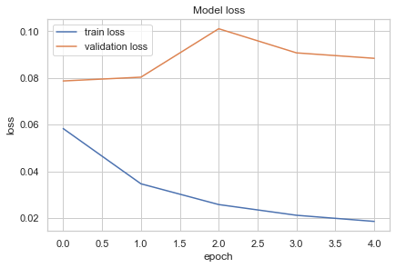

```python
Trained_model = tf.keras.models.load_model(model_path_lstm)
plt.plot(history.history['loss'])
plt.plot(history.history['val_loss'])
plt.title('Model loss')
plt.ylabel('loss')
plt.xlabel('epoch')
plt.legend(['train loss', 'validation loss'], loc='upper left')
plt.rcParams["figure.figsize"] = [16,9]
plt.show()
```

BiDirectional LSTM

```python
#Define the bidirectional LSTM model.
Bi_lstm_model = tf.keras.models.Sequential([
 tf.keras.layers.Bidirectional(tf.keras.layers.LSTM(150,return_sequences=True),
                               input_shape=x_train_multi.shape[-2:]),tf.keras.layers.Dense(20, activation='tanh'),
                               tf.keras.layers.Bidirectional(tf.keras.layers.LSTM(150)),
 tf.keras.layers.Dense(20, activation='tanh'),
 tf.keras.layers.Dropout(0.2),

 tf.keras.layers.Dense(units=horizon),
])
Bi_lstm_model.compile(optimizer='adam', loss='mae')
```

```python
model_path_Bidir = r'Bi_Directional_LSTM_Multivariate_168_timestep_24_pred.h5'
```

```python
EVALUATION_INTERVAL = 150
EPOCHS = 15
history = Bi_lstm_model.fit(train_data_multi, epochs=EPOCHS,steps_per_epoch=EVALUATION_INTERVAL,validation_data=val_data_multi,
validation_steps=150,verbose =1,callbacks =[tf.keras.callbacks.EarlyStopping(monitor='val_loss', min_delta=0, patience=4,
verbose=1, mode='min'),tf.keras.callbacks.ModelCheckpoint(model_path_Bidir,monitor='val_loss', save_best_only=True, mode='min',verbose=0)])
```

```
Epoch 00015: early stopping
```

```python
model_path_Bidir = '/content/sample_data/Bi_Directional_LSTM_Multivariate_168_timestep_24_pred-3.h5'
Trained_model_Bidri_lstm = tf.keras.models.load_model(model_path_Bidir)
```

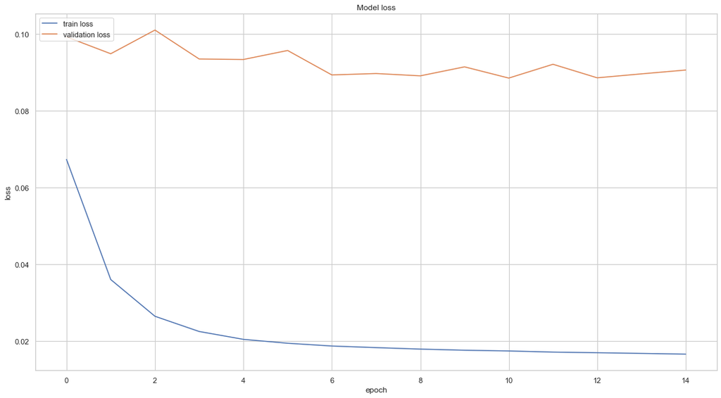

```python
Trained_model = tf.keras.models.load_model(model_path_Bidir)
plt.plot(history.history['loss'])
plt.plot(history.history['val_loss'])
plt.title('Model loss')
plt.ylabel('loss')
plt.xlabel('epoch')
plt.legend(['train loss', 'validation loss'], loc='upper left')
plt.rcParams["figure.figsize"] = [16,9]
plt.show()
```

GRU Model

```python
#Define the GRU model.
GRU_model = tf.keras.models.Sequential([
 tf.keras.layers.GRU(units =150, input_shape=x_train_multi.shape[-2:],return_sequences=True),
 tf.keras.layers.Dropout(0.2),
 tf.keras.layers.GRU(units=100,return_sequences=True),
 tf.keras.layers.Dropout(0.2),
 tf.keras.layers.GRU(units=50,return_sequences=False),
 tf.keras.layers.Dropout(0.2),
 tf.keras.layers.Dense(units=horizon),
])
GRU_model.compile(optimizer='adam', loss='mae')
```

```python
model_path_gru = r'GRU_168_timestep_24_pred.h5'
```

```python
EVALUATION_INTERVAL = 150
EPOCHS = 15
history = GRU_model.fit(train_data_multi, epochs=EPOCHS,steps_per_epoch=EVALUATION_INTERVAL,validation_data=val_data_multi,
validation_steps=150,verbose =1,callbacks =[tf.keras.callbacks.EarlyStopping(monitor='val_loss', min_delta=0, patience=4,
verbose=1, mode='min'),tf.keras.callbacks.ModelCheckpoint(model_path_gru,monitor='val_loss', save_best_only=True, mode='min',verbose=0)])
```

```
Epoch 00006: early stopping
```

```python
model_path_gru = '/content/sample_data/GRU_168_timestep_24_pred_MAE_11.h5'
Trained_model_Gru = tf.keras.models.load_model(model_path_gru)
```

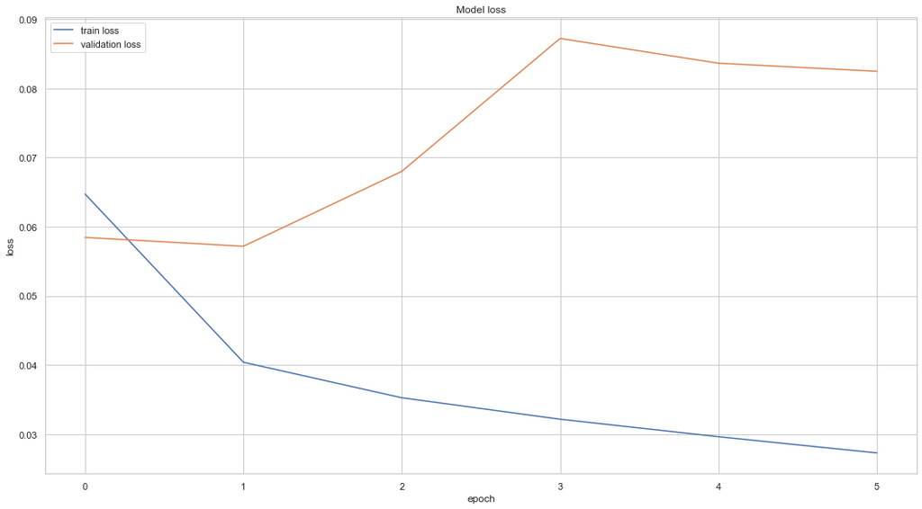

```python
Trained_model = tf.keras.models.load_model(model_path_gru)
plt.plot(history.history['loss'])
plt.plot(history.history['val_loss'])
plt.title('Model loss')
plt.ylabel('loss')
plt.xlabel('epoch')
plt.legend(['train loss', 'validation loss'], loc='upper left')
plt.rcParams["figure.figsize"] = [16,9]
plt.show()
```

```python
#Define the auto-encoder LSTM model.
ED_lstm_model = tf.keras.models.Sequential([
 tf.keras.layers.LSTM(units=128, activation='relu', input_shape=x_train_multi.shape[-2:], return_sequences=True),
 tf.keras.layers.LSTM(units=64, activation='relu',  return_sequences=True),
 tf.keras.layers.LSTM(units=32,return_sequences=True),
 tf.keras.layers.LSTM(units=8),
 tf.keras.layers.Dropout(rate=0.2),
 tf.keras.layers.RepeatVector(y_train_multi.shape[1]),
 tf.keras.layers.LSTM(units=8,activation='relu', return_sequences=True),
 tf.keras.layers.LSTM(units=32,activation='relu' , return_sequences=True),
 tf.keras.layers.LSTM(units=64, activation='relu' ,return_sequences=True),
 tf.keras.layers.LSTM(units=128,return_sequences=True),
 tf.keras.layers.Dropout(rate=0.2),
 tf.keras.layers.TimeDistributed(tf.keras.layers.Dense(units=horizon))])
ED_lstm_model.compile(optimizer='adam', loss='mae')
```

```python
ED_lstm_model = tf.keras.models.Sequential([
 tf.keras.layers.LSTM(100, input_shape=x_train_multi.shape[-2:], return_sequences=True),
 tf.keras.layers.LSTM(units=50,return_sequences=True),
 tf.keras.layers.LSTM(units=25),
 tf.keras.layers.RepeatVector(y_train_multi.shape[1]),
 tf.keras.layers.LSTM(units=50,return_sequences=True),
 tf.keras.layers.LSTM(units=25,return_sequences=True),
 tf.keras.layers.TimeDistributed(tf.keras.layers.Dense(units=1))])
ED_lstm_model.compile(optimizer='adam', loss='mae')
```

```python
model_path_autoencoder = r'Autoencoder_LSTM_Multivariate_168_timestep_24_pred.h5'
```

```python
EVALUATION_INTERVAL = 150
EPOCHS = 15
history = ED_lstm_model.fit(train_data_multi, epochs=EPOCHS,steps_per_epoch=EVALUATION_INTERVAL,validation_data=val_data_multi,
validation_steps=150,verbose =1,callbacks =[tf.keras.callbacks.EarlyStopping(monitor='val_loss', min_delta=0, patience=4,
verbose=1, mode='min'),tf.keras.callbacks.ModelCheckpoint(model_path_autoencoder,monitor='val_loss', save_best_only=True, mode='min',verbose=0)])
```

```
Epoch 00006: early stopping
```

```python
model_path_autoencoder = '/content/sample_data/Autoencoder_LSTM_Multivariate_168_timestep_24_pred-4.h5'
Trained_model_Auto = tf.keras.models.load_model(model_path_autoencoder)
```

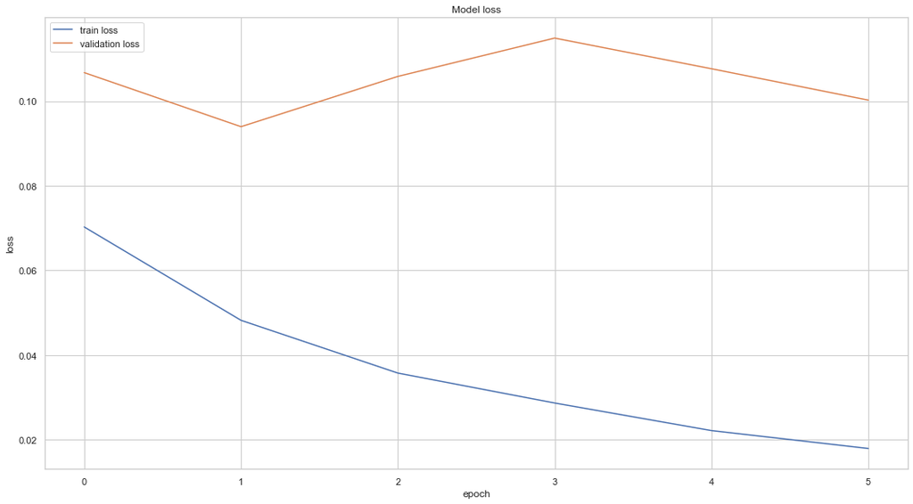

```python
Trained_model = tf.keras.models.load_model(model_path_autoencoder)
plt.plot(history.history['loss'])
plt.plot(history.history['val_loss'])
plt.title('Model loss')
plt.ylabel('loss')
plt.xlabel('epoch')
plt.legend(['train loss', 'validation loss'], loc='upper left')
plt.rcParams["figure.figsize"] = [16,9]
plt.show()
```

Load the best weights into the model.

We need to forecast the next 24 steps, so let’s take the last 7 days of data from the test set and forecast

```python
from sklearn import metrics
def timeseries_evaluation_metrics_func(y_true, y_pred):
  def mean_absolute_percentage_error(y_true, y_pred):
    y_true, y_pred = np.array(y_true), np.array(y_pred)
    return np.mean(np.abs((y_true - y_pred) / y_true)) * 100
  print('Evaluation metric results:-')
  print(f'MSE is : {metrics.mean_squared_error(y_true, y_pred)}')
  print(f'MAE is : {metrics.mean_absolute_error(y_true, y_pred)}')
  print(f'RMSE is : {np.sqrt(metrics.mean_squared_error (y_true, y_pred))}')
  print(f'MAPE is : {mean_absolute_percentage_error(y_true,y_pred)}')
  print(f'R2 is : {metrics.r2_score(y_true, y_pred)}',end='\n\n')
```

# Part 4 - Testing

Testing for multiple days,

```python
test_15_Nov_2012 = x_test_multi[0]
test_16_Nov_2012 = x_test_multi[1]
#test_30_Nov_2012 = x_test_multi[15]
#test_16_dec_2012 = x_test_multi[31]
#test_31_dec_2012 = x_test_multi[46]
```

```python
test_15_Nov_2012.shape
```

```
(168, 13)
```

Rescaled for 3D input

```python
val_rescaled_1_nov = test_15_Nov_2012.reshape(1, test_15_Nov_2012.shape[0], test_15_Nov_2012.shape[1])
val_rescaled_2_nov = test_16_Nov_2012.reshape(1, test_16_Nov_2012.shape[0], test_16_Nov_2012.shape[1])
#val_rescaled_3_nov = test_30_Nov_2012.reshape(1, test_30_Nov_2012.shape[0], test_30_Nov_2012.shape[1])
#val_rescaled_4_nov = test_16_dec_2012.reshape(1, test_16_dec_2012.shape[0], test_16_dec_2012.shape[1])
```

```python
y_test_15_nov =y_test[y_test.index =='2012-11-15'].values
y_test_16_nov =y_test[y_test.index =='2012-11-16'].values
y_test_30_nov =y_test[y_test.index =='2012-11-30'].values
y_test_16_dec =y_test[y_test.index =='2012-12-16'].values
```

```python
y_test_15_nov
```

```
array([ 34.,  16.,   7.,   2.,   5.,  37., 147., 410., 646., 323., 153.,
       166., 213., 217., 201., 217., 342., 563., 573., 386., 285., 224.,
       153., 125.])
```

```python
# MAE 11.65
Predicted_results = Trained_model_lstm.predict(val_rescaled_1_nov)
Predicted_results_Inv_trans = y_scaler.inverse_transform(Predicted_results)
timeseries_evaluation_metrics_func(y_test_15_nov,Predicted_results_Inv_trans[0])
Predicted_results_Inv_trans
```

```
Evaluation metric results:-
MSE is : 232.6625467272868
MAE is : 11.652747318148613
RMSE is : 15.253279867860774
MAPE is : 12.24049231654725
R2 is : 0.9929450289429755
```

```
array([[ 29.231655 ,   7.9016175,   9.213968 ,   1.8461155,   9.087922 ,
         34.690235 , 127.56065  , 379.54172  , 628.4044   , 310.94937  ,
        150.65652  , 177.78201  , 221.77194  , 220.77873  , 198.56018  ,
        221.09435  , 327.216    , 605.1717   , 581.4398   , 398.83652  ,
        274.73856  , 206.22935  , 168.34096  , 101.32557  ]],
      dtype=float32)
```

```python
# MAE = 26
Predicted_results = Trained_model_Bidri_lstm.predict(val_rescaled_1_nov)
Predicted_results_Inv_trans = y_scaler.inverse_transform(Predicted_results)
timeseries_evaluation_metrics_func(y_test_15_nov,Predicted_results_Inv_trans[0])
Predicted_results_Inv_trans
```

```
Evaluation metric results:-
MSE is : 1484.9018084091358
MAE is : 26.222935537497204
RMSE is : 38.53442368077062
MAPE is : 22.058137527653997
R2 is : 0.9549736757023938
```

```
array([[ 41.979515,  18.780315,   9.721741,   5.932409,   4.290349,
         25.041458, 103.71289 , 297.3239  , 551.33514 , 283.1513  ,
        142.05994 , 158.30048 , 194.50067 , 186.98999 , 181.26804 ,
        228.16014 , 330.43835 , 567.3398  , 517.0432  , 335.98016 ,
        247.73613 , 203.33151 , 156.95789 ,  98.01779 ]], dtype=float32)
```

```python
# MAE 11.41
Predicted_results = Trained_model_Gru.predict(val_rescaled_1_nov)
Predicted_results_Inv_trans = y_scaler.inverse_transform(Predicted_results)
timeseries_evaluation_metrics_func(y_test_15_nov,Predicted_results_Inv_trans[0])
Predicted_results_Inv_trans
```

```
Evaluation metric results:-
MSE is : 311.37718236378663
MAE is : 11.41776828467846
RMSE is : 17.64588287289096
MAPE is : 22.785283296975024
R2 is : 0.9905581837717556
```

```
array([[ 3.56246223e+01,  1.48449736e+01, -2.14565396e-01,
         8.07765865e+00,  6.35040188e+00,  3.83434982e+01,
         1.40861908e+02,  3.95164490e+02,  6.20287170e+02,
         3.12164795e+02,  1.41213989e+02,  1.58921722e+02,
         2.31689835e+02,  2.30670074e+02,  1.87187607e+02,
         2.23157501e+02,  3.47930847e+02,  6.30673096e+02,
         5.74250061e+02,  3.93911987e+02,  2.83202393e+02,
         2.29423553e+02,  1.73065720e+02,  1.08507935e+02]], dtype=float32)
```

```python
Predicted_results = Trained_model_Auto.predict(val_rescaled_1_nov)
Predicted_results_Inv_trans = y_scaler.inverse_transform(Predicted_results.reshape(-1,1))
timeseries_evaluation_metrics_func(y_test_15_nov,Predicted_results_Inv_trans)
```

```
WARNING:tensorflow:5 out of the last 12 calls to <function Model.make_predict_function.<locals>.predict_function at 0x7f0118491f80> triggered tf.function retracing. Tracing is expensive and the excessive number of tracings could be due to (1) creating @tf.function repeatedly in a loop, (2) passing t…
Evaluation metric results:-
MSE is : 10881.167448128892
MAE is : 53.17139352361361
RMSE is : 104.31283453213652
MAPE is : 879.7868298609036
R2 is : 0.6700529479582835
```

tested for all test cases, and concluded in report, not adding here to avoid confusion

Lets Start with Sarimax

- Data prepartion

```python
# lets keep it handy for future use In order to stationarize the data, we need to remove the trend and seasonal components.
#We can do that by differencing the data by the desired order of differencing. Intuitively, this is analogous to taking the derivatives of functions.
# invert differenced forecast
def invert_diff(series, first_element_before):
    cumsum = series.cumsum()
    return cumsum.fillna(0) + first_element_original
```

```python
x_train_traditional.columns
x_train_traditional_1 = finaldf_train
x_train_traditional_1[:4]
```

| dteday | yr | hr | holiday | workingday | temp | hum | windspeed | t_24 | t_23 | t_22 | t_21 | t_20 | t_19 | t_18 | t_17 | t_16 | t_15 | t_14 | t_13 | t_12 | t_11 | t_10 | t_9 | t_8 | t_7 | t_6 | t_5 | t_4 | t_3 | … |
| --- | --- | --- | --- | --- | --- | --- | --- | --- | --- | --- | --- | --- | --- | --- | --- | --- | --- | --- | --- | --- | --- | --- | --- | --- | --- | --- | --- | --- | --- | --- |
| 2011-01-03 | 0.0 | 0 | 0.0 | 1.0 | 0.22 | 0.44 | 0.3582 | 17.0 | 17.0 | 9.0 | 6.0 | 3.0 | 0.0 | 2.0 | 1.0 | 8.0 | 20.0 | 53.0 | 70.0 | 93.0 | 75.0 | 59.0 | 74.0 | 76.0 | 65.0 | 53.0 | 30.0 | 22.0 | 31.0 | … |
| 2011-01-03 | 0.0 | 1 | 0.0 | 1.0 | 0.20 | 0.44 | 0.4179 | 17.0 | 9.0 | 6.0 | 3.0 | 0.0 | 2.0 | 1.0 | 8.0 | 20.0 | 53.0 | 70.0 | 93.0 | 75.0 | 59.0 | 74.0 | 76.0 | 65.0 | 53.0 | 30.0 | 22.0 | 31.0 | 9.0 | … |
| 2011-01-03 | 0.0 | 2 | 0.0 | 1.0 | 0.16 | 0.47 | 0.3881 | 9.0 | 6.0 | 3.0 | 0.0 | 2.0 | 1.0 | 8.0 | 20.0 | 53.0 | 70.0 | 93.0 | 75.0 | 59.0 | 74.0 | 76.0 | 65.0 | 53.0 | 30.0 | 22.0 | 31.0 | 9.0 | 8.0 | … |
| 2011-01-03 | 0.0 | 3 | 0.0 | 1.0 | 0.16 | 0.47 | 0.3881 | 6.0 | 3.0 | 0.0 | 2.0 | 1.0 | 8.0 | 20.0 | 53.0 | 70.0 | 93.0 | 75.0 | 59.0 | 74.0 | 76.0 | 65.0 | 53.0 | 30.0 | 22.0 | 31.0 | 9.0 | 8.0 | 5.0 | … |

```python
x_test_traditional[:1]
```

|  | season_sin | season_cos | weathersit_sin | weathersit_cos | yr | workingday | temp | hum | t_24 | t_23 | t_22 | t_21 | t_20 | t_19 | t_18 | t_17 | t_16 | t_15 | t_14 | t_13 | t_12 | t_11 | t_10 | t_9 | t_8 | t_7 | t_6 | t_5 | t_4 | … |
| --- | --- | --- | --- | --- | --- | --- | --- | --- | --- | --- | --- | --- | --- | --- | --- | --- | --- | --- | --- | --- | --- | --- | --- | --- | --- | --- | --- | --- | --- | --- |
| 0 | -2.449294e-16 | 1.0 | 1.224647e-16 | -1.0 | 1.0 | 1.0 | 0.26 | 0.65 | 0.031621 | 0.01581 | 0.001318 | 0.006588 | 0.007905 | 0.051383 | 0.192358 | 0.546772 | 0.910408 | 0.437418 | 0.225296 | 0.198946 | 0.316206 | 0.28195 | 0.238472 | 0.342556 | 0.422925 | 0.768116 | 0.747036 | 0.521739 | 0.351779 | … |

x_train_traditional_sarimax is training data and x_test_traditional_sarimax is testing data, we dnt lagged values here as sarimax takes care of it

holiday, workingday,weekday and mnth less pvalue

```python
x_train_traditional_sarimax = x_train_traditional_1[['season_sin', 'season_cos', 'weathersit_sin', 'weathersit_cos', 'yr',
       'workingday', 'temp', 'hum','weekday_sin', 'weekday_cos', 'mnth_sin', 'mnth_cos', 'hr_sin',
       'hr_cos' ]]

x_train_traditional_sarimax[:2]
```

| dteday | season_sin | season_cos | weathersit_sin | weathersit_cos | yr | workingday | temp | hum | weekday_sin | weekday_cos | mnth_sin | mnth_cos | hr_sin | hr_cos |
| --- | --- | --- | --- | --- | --- | --- | --- | --- | --- | --- | --- | --- | --- | --- |
| 2011-01-03 | 1.0 | 6.123234e-17 | 1.0 | 6.123234e-17 | 0.0 | 1.0 | 0.22 | 0.44 | 0.781831 | 0.62349 | 0.5 | 0.866025 | 0.000000 | 1.000000 |
| 2011-01-03 | 1.0 | 6.123234e-17 | 1.0 | 6.123234e-17 | 0.0 | 1.0 | 0.20 | 0.44 | 0.781831 | 0.62349 | 0.5 | 0.866025 | 0.258819 | 0.965926 |

```python
x_test_traditional_sarimax = x_test_traditional[['season_sin', 'season_cos', 'weathersit_sin', 'weathersit_cos', 'yr',
       'workingday', 'temp', 'hum','weekday_sin', 'weekday_cos', 'mnth_sin', 'mnth_cos', 'hr_sin',
       'hr_cos' ]]

x_test_traditional_sarimax [:2]
```

|  | season_sin | season_cos | weathersit_sin | weathersit_cos | yr | workingday | temp | hum | weekday_sin | weekday_cos | mnth_sin | mnth_cos | hr_sin | hr_cos |
| --- | --- | --- | --- | --- | --- | --- | --- | --- | --- | --- | --- | --- | --- | --- |
| 0 | -2.449294e-16 | 1.0 | 1.224647e-16 | -1.0 | 1.0 | 1.0 | 0.26 | 0.65 | -0.433884 | -0.900969 | -0.5 | 0.866025 | 0.000000 | 1.000000 |
| 1 | -2.449294e-16 | 1.0 | 1.224647e-16 | -1.0 | 1.0 | 1.0 | 0.26 | 0.65 | -0.433884 | -0.900969 | -0.5 | 0.866025 | 0.258819 | 0.965926 |

```python
y_test_sarimax = pd. DataFrame(y_test, columns=['cnt'],index=x_test_traditional_sarimax.index)
```

```python
y_train
```

```
array([[0.00511771],
       [0.00204708],
       [0.        ],
       ...,
       [0.21801433],
       [0.17707267],
       [0.08904811]])
```

Input ranges

```python
start_point = '2012-07-01'                      # Set 1 start training date
start_point_2 = '2012-10-13'                    # Set 2 start training date
test_train_1 = '2012-07-31'                     # test on training data

end_point_train_1 = '2012-07-31'               # end date of trainining set 1
end_point_train_2 = '2012-11-14'               # end date of trainining set 2

start_point_x_test = '2012-08-01'              # test on training set 1
start_point_validation = '2012-11-15'          # validate on training set 2


train_exo_1 = x_train_traditional_sarimax[(x_train_traditional_sarimax.index >= start_point) & (x_train_traditional_sarimax.index <= end_point_train_1)].values   # first Train
train_endo_1 = y_train_sarimax[(y_train_sarimax.index >= start_point) & (y_train_sarimax.index <= end_point_train_1)].values

Train_test_exo_1 =  x_train_traditional_sarimax[x_train_traditional_sarimax.index == test_train_1].values                                                     # test on train
Train_test_endo_1 = y_train_sarimax[y_train_sarimax.index == end_point_train_1]
Train_test_endo_1 = y_scaler.inverse_transform(Train_test_endo_1.values.reshape(-1,1))                       # inverse transform to make it static

test_exo_1 = x_train_traditional_sarimax.loc[(x_train_traditional_sarimax.index == start_point_x_test)].values           # test
test_endo_1 = y_train_sarimax[y_train_sarimax.index == start_point_x_test]
test_endo_1 = y_scaler.inverse_transform(test_endo_1.values.reshape(-1,1))

train_exo_2 = x_train_traditional_sarimax[(x_train_traditional_sarimax.index >= start_point_2) & (x_train_traditional_sarimax.index <= end_point_train_2)].values     # second Train
train_endo_2 = y_train_sarimax[(y_train_sarimax.index >= start_point_2) & (y_train_sarimax.index <= end_point_train_2)].values

validation_exo_1 = x_test_traditional_sarimax.loc[(x_test_traditional_sarimax.index == start_point_validation)].values   # validated
validation_endo_1 = y_test_sarimax[y_test_sarimax.index == start_point_validation]
#validation_endo_1 = y_scaler.inverse_transform(validation_endo_1.values.reshape(-1,1))
```

```python
print(train_exo_2.shape)
print(validation_exo_1.shape)
```

```
(792, 14)
(24, 14)
```

Grid Search

```python
import warnings
warnings.filterwarnings("ignore")
import itertools
p = range(0,3)
q = range(0,3)
D= [0,1]
d = [1]
s = [24,7]
Final_1 = pd.DataFrame()
pdq = list(itertools.product(p,d,q))
seasonal_pdq = list(itertools.product(p,D,q,s))

for param in pdq:
  for param_seasonal in seasonal_pdq:
    try:
      print('Starting')
      mod_1 = sm.tsa.statespace.SARIMAX(train_endo_1 , exog = train_exo_1, order = param, seasonal_order = param_seasonal, enforce_stationarity = False
                                      , enforece_invertibility= False)
      results = mod_1.fit(disp=0)

      forecast_train = results.predict(start = 0, end = 23 , exog =Train_test_exo_1)
      MAE_train = metrics.mean_absolute_error(Train_test_endo_1, y_scaler.inverse_transform(np.array(forecast_train).reshape(-1,1)))
      Forecast_test = results.predict(start =0, end = 23 , exog   = test_exo_1)
      MAE_test = metrics.mean_absolute_error(test_endo_1,  y_scaler.inverse_transform(np.array(Forecast_test).reshape(-1,1)))

      mod_2 = sm.tsa.statespace.SARIMAX(train_endo_2 , exog = train_exo_2, order = param, seasonal_order = param_seasonal, enforce_stationarity = False
                                      , enforece_invertibility= False)

      results_2 = mod_2.fit(disp=0)

      Forecast_validate = results_2.predict(start =0, end = 23, exog   = validation_exo_1)
      MAE_validate = metrics.mean_absolute_error(validation_endo_1, y_scaler.inverse_transform(np.array(Forecast_validate).reshape(-1,1)))
      print(MAE_validate)
      def mean_absolute_percentage_error(y_true, y_pred):
        y_true, y_pred = np.array(y_true), np.array(y_pred)
        return np.mean(np.abs((y_true - y_pred)/ y_true))*100

      MAPE_test = mean_absolute_percentage_error(test_endo_1,  y_scaler.inverse_transform(np.array(Forecast_test).reshape(-1,1)))
      MAPE_train = mean_absolute_percentage_error(Train_test_endo_1, y_scaler.inverse_transform(np.array(forecast_train).reshape(-1,1)))
      MAPE_validate = mean_absolute_percentage_error(validation_endo_1, y_scaler.inverse_transform(np.array(Forecast_validate).reshape(-1,1)))

      print('oh yes *_* {} {}'.format(param,param_seasonal))

      Final_1 =Final_1.append({'Order': param,'Seasonal_Order':param_seasonal,'MAE_test': MAE_test,'MAE_validate': MAE_validate,'MAE_train': MAE_train,'MAPE_test': MAPE_test,
                          'MAPE_validate': MAPE_validate,'MAPE_train':MAPE_train
                          ,'AIC':results.aic},  ignore_index=True)

    except:
      continue
```

```python
Final_1.to_csv('GridSearch_One_Month_Train_Sarimax.csv',index= False, header=True)
```